# ProjektFilmy.FakSpiewakSmuda

Katarzyna Fąk, Piotr Smuda, Martyna Śpiewak

2015-05-21

# Faza I

## Charakterystyki

Podstawowe charakterystyki dotyczące pobranych filmów:

1. **Title** - tytuł filmu
2. **Year** - rok produkcji
3. **Duration** - czas trwania
4. **Genres** - gatunek (*Action, Adventure, Animation, Biography, Comedy, Crime, Documentary, Drama,Family, Fantasy, Game-Show, History, Horror, Music, Musical, Mystery, News, Reality-TV, Romance, Sci-Fi, Sitcom, Sport, Talk-Show, Thriller, War, Western*)
5. **Rating** - srednia ocena filmu
6. **Votes** - liczba głosów oddanych na dany film
7. **DirectedBy** - rezyser
8. **Cast** - obsada
9. **Writing** - scenariusz
10. **ProducedBy** - producent
11. **MusicBy** - muzyka
12. **CinematographyBy** - zdjecia
13. **Production_countries** - kraj podukcji filmu
14. **Language** - jezyk filmu
15. **Color** - wersja kolorystyczna
16. **Keywords** - słowa klucze powiazane z danym filmem

Szczegółowe statystyki:

17. **Males, Females** - srednia ocena ze wzgledu na płec
18. **Aged_under_18, Aged_18-29, Aged_30-44, Aged_45+** - srednia ocena w danej kategorii wiekowej
19. **Males_under_18, Males_Aged_18,29, Males_Aged_30-44, Males_Aged_45+** - srednia ocen przyznanych przez mezczyzn w róznych kategoriach wiekowych
20. **Females_under_18, Females_Aged_18-29, Females_Aged_30-44, Females_Aged_45+** - srednia ocen przyznanych przez kobiety w róznych kategoriach wiekowych
21. **IMDb_staff, Top_1000_voters, US_users, Non-US_users** - srednie oceny w innych kategoriach
22. **Vote_10 - Vote_1** - liczba głosów na dana ocene

Do pakietu dołączone są dwie ramki danych `MoviesIMDB` oraz `movies10IMDB`. W pierwszej z nich są informacje na temat **102607** pobranych filmów z przedziału czasowego 1894 - 2014. Natomiast w drugiej znajdują się informacje na temat **10494** z przedziału 1900 - 2014, wybrane w następujacy sposób:

1. 1900 - 1908 - wszystkie;
2. 1909 - 1960 - po 50 filmów z każdego roku;
3. 1961 - 1990 - po 100 filmów z każdego roku;
4. 1991 - 2014 - po 200 filmów z każdego roku.

# Faza II

W kolejnej fazie projektu naszym zadaniem było zbudowanie macierzy odległośći pomiędzy filmami opartą o zebrane dane.

## Macierze podobieństwa

### Ogólny sposób wyznaczania ostatniej macierzy podobieństwa

Ostateczną macierz podobieństwa dla zebranych przez nas charakterystyk, wyznaczamy w ten sposób, że pojedyńcze macierze charakterystyk dodajemy do siebie a następnie każdy element w wynikowej macierzy dzielimy przez liczbę wszystkich sumowanych macierzy.

### Wybrane charakterystyki do macierzy podobieństw

Poniższe macierze podobieństwa mają takie same nazwy jak kolumny w ramce `MoviesIMDB` i zostały zapisane w formacie `.rda`.

### Tytuł (Title)

##### Sposób obliczenia

$P=\frac{\text{moc przecięcia słów w tytułach}}{\text{moc sumy słów w tytułach}}$

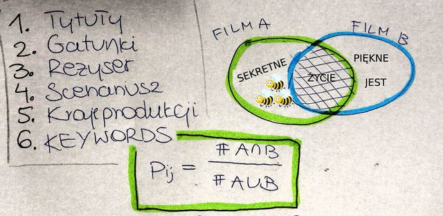

### Rok (Year)

#### Koszyki

Podział okresów w kinematografii dzieli się następująco:

1. 1894-1930 - kino nieme;
2. 1931-1955 - początek filmów z dźwiękiem;
3. 1956-1975 - nurty “nowej fali”;
4. 1976-1995 - początek kina współczesnego;
5. 1996-2014 - kino współczesne;

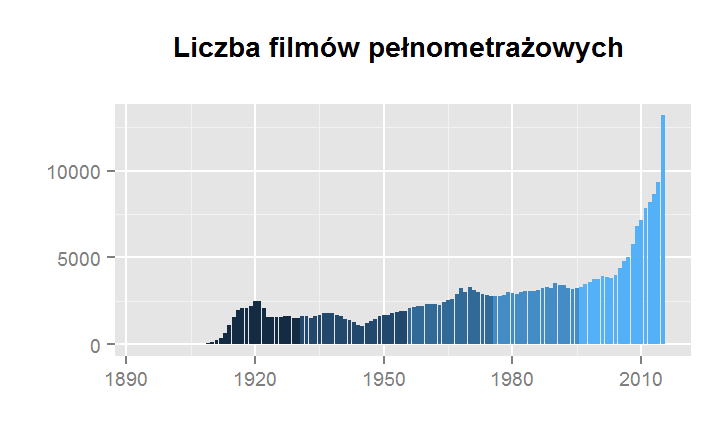

##### Sposób obliczenia

$P=\frac{\text{liczba koszyków - |nr koszyk 1 - nr koszyk 2|}}{\text{liczba koszyków}}$

### Gatunki (Genres)

##### Sposób obliczenia

$P=\frac{\text{moc przecięcia gatunków}}{\text{moc sumy gatunków}}$

### Reżyser (Directedby)

##### Sposób obliczenia

$P=\frac{\text{moc przecięcia reżyserów}}{\text{moc sumy reżyserów}}$

### Obsada (Cast)

##### Sposób obliczenia

$P=0.8\cdot\frac{\text{moc przecięcia aktorów z I grupy}}{\text{moc sumy aktorówz I grupy}}+0.2\cdot\frac{\text{moc przecięcia aktorów z II grupy}}{\text{moc sumy aktorówz II grupy}}$

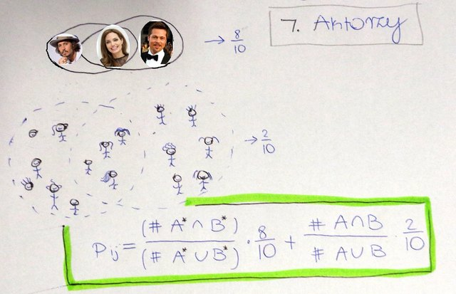

### Scenariusz (Writing)

##### Sposób obliczenia

$P=\frac{\text{moc przecięcia scenarzystów}}{\text{moc sumy scenarzystów}}$

### Kraj produkcji (Production_countries)

##### Sposób obliczenia

$P=\frac{\text{moc przecięcia krajów}}{\text{moc sumy krajów}}$

### Kolor (Color)

##### Sposób obliczenia

$P=\begin{cases} 1 \text{ dla takich samych typów} \\ 0 \text{ dla różnych typów}\end{cases}$

### Słowa kluczowe (Keywords)

##### Sposób obliczenia

$P=\frac{\text{moc przecięcia słów kluczowych}}{\text{moc sumy słów kluczowych}}$

### Oceny (Overall_Rating)

**(Males, Females, Aged_under_18, Males_under_18, Females_under_18, Aged_18.29, Males_Aged_18.29, Females_Aged_18.29, Aged_30.44, Males_Aged_30.44, Females_Aged_30.44, Aged_45., Males_Aged_45., Females_Aged_45., IMDb_staff)**

##### Sposób obliczenia

$P=\begin{cases} \frac{10 - |\text{ocena 1 - ocena 2}|}{10} \text{ gdy żadna ocenia nie jest "-1"} \\ 0 \text{ w p.p.}\end{cases}$

# Przykład

```r
library(ProjektFilmy.FakSpiewakSmuda)
```

Wszystkie wykorzystywane funkcje przy tworzeniu tego projektu znajdują się w pakiecie **ProjektFilmy.FakSpiewakSmuda**. Nazwy funkcji zaczynające się od prefiksu **imdb_** dotyczą funkcji wykorzystywanych do pobierania informacji z strony imdb.com. Natomiast funkcje zaczynające się od prefiksu **movies_** są wykorzystywane do stworzenia macierzy podobieństwa dla informacji o filmach pobranych w fazie I.

Jeżeli chcemy pobrać podstawowe informacje na temat filmów z wybranego przedziału czasowgo, możemy wykorzystać w tym celu funkcję `imbd_download`, natomiast jeśli chcielibyśmy pobrać szczegółowe informacje na temat statystyk dotyczących danego filmu możemy wykorzystać funkcję `imdb_save_table_rating`.

Jeżeli chcemy użyć powyższych funkcji musimy posiadać unikalne nazwy filmów ze strony imdb.com. Możemy skorzystać z gotowej ramki danych dostępnej w pakiecie `MoviesLinks`

```r
head(MoviesLinks, 5)
```

```
##   year                                link
## 1 1894 http://www.imdb.com/title/tt0000009
## 2 1897 http://www.imdb.com/title/tt0229676
## 3 1898 http://www.imdb.com/title/tt0219574
## 4 1898 http://www.imdb.com/title/tt0221654
## 5 1898 http://www.imdb.com/title/tt0229764
```

lub pobrać takie infromacje korzystając z funkcji `imdb_download_movie_url_year`.

```r
imbd_download_info(from = 2000, to = 2014)

imdb_save_table_rating(from = 2000, to = 2014)
```

Pobrane informacje i statystyki dotyczące filmów zapisały się odpowiednio w katalogu domowym w folderze `dane\\glowne` oraz `dane\\statystyki` w formacie `.csv`.

W naszym pakiecie przygotowane są gotowe ramki danych `MoviesIMDB` oraz `movies10IMDB`.

|  | Id | Title | Year | Duration | Genres | Directedby | Cast | Writing | Producedby | Musicby | Cinematographyby | Production_countries | Language | Color | Keywords | Overall_Rating | Votes | Males | Females | Aged_under_18 | Males_under_18 | Females_under_18 | Aged_18.29 | Males_Aged_18.29 | Females_Aged_18.29 | Aged_30.44 | Males_Aged_30.44 | Females_Aged_30.44 | Aged_45. | … |
| --- | --- | --- | --- | --- | --- | --- | --- | --- | --- | --- | --- | --- | --- | --- | --- | --- | --- | --- | --- | --- | --- | --- | --- | --- | --- | --- | --- | --- | --- | --- |
| 10494 | tt2183034 | Earth to Echo | 2014 | 91 | Adventure,Family,Sci-Fi | Dave Green | Teo Halm,Astro,Reese Hartwig,Ella Wahlestedt,Jason Gray-Stanford,Algee Smith,Cassius Willis,Sonya Leslie,Kerry O’Malley,Virginia Louise Smith,Peter Mackenzie,Valerie Wildman,Roger Hewlett,Mary Pat Gle… | Henry Gayden,Henry Gayden,Andrew Panay | Jason Beckman,Adam Blum,Robbie Brenner,Jason Colodne,Ken Halsband,Mark Benton Johnson,Jack Kavanaugh,Ryan Kavanaugh,David Miller,Andrew Panay,Patrick Peach,Tucker Tooley | Joseph Trapanese | Maxime Alexandre | USA | English | Color | alien,no opening credits,construction worker,bar,building spaceship,moving,packing,foster child,pov camera,alien creature,bicycle helmet,inside space ship,space ship,alien friendship,friendly alien,su… | 5.7 | 12006 | 5.6 | 6.2 | 6.9 | 6.6 | 7.5 | 5.9 | 5.8 | 6.2 | 5.6 | 5.5 | 6.1 | 5.3 | … |

Teraz aby stworzyć macierze podobieństwa będziemy korzystać z funkcji `doSimilarityMatrix`. Funkcja ta na wejściu przyjmuje parametry

- `po_czym` - nazwa charakterystyki względem, której będzie liczona macierz podobieństwa,
- `n` - liczba filmów, dla których ma być utworzona macierz, liczymy od filmu najpóźniej wyprodukowanego do filmu najwcześniej wyprodukowane oraz
- `FUN` - funkcja, odpowiadająca sposobie liczenia danej charakterystyki:
  - `moviesIntersect` - Title, Genres, DirectedBy, Writing, ProducedBy, MusicBy, CinematographyBy, Production_countries, Language, Color, Keywords;
  - `moviesWeightedIntersect` - Cast;
  - `moviesDist5` - Year;
  - `moviesDist10` - Overall_Rating, Males, Females, Aged_under_18, Males_under_18, Females_under_18, Aged_18.29, Males_Aged_18.29, Females_Aged_18.29, Aged_30.44, Males_Aged_30.44, Females_Aged_30.44, Aged_45., Males_Aged_45., Females_Aged_45., IMDb_staff.

```r
movies_doSimilarityMatrix('Keywords', 4000, moviesIntersect)

movies_doSimilarityMatrix('Overall_Ratings', 4000, moviesDist10)
```

Każdą wyliczoną macierz podobieństwa możemy również znaleźć w naszym pakiecie (liczyliśmy dla 4000 najnowszych filmów). Ramka z danymi ma taką samą nazwę jak odpowiadająca jej charakterystyka. Wyjątkiem jest ramka `moviesDist`, w której znajduje się podsumowanie najważniejszych naszym zdaniem charakterystyk. Aby stworzyć taką ramkę użyliśmy w tym celu funkcji `movies_Dist`, która liczy średnią arytmetyczną z podanej listy macierzy, ponadto jest czuła na braki danych.

```r
movies_Dist(list(Title, Genres, Directedby, Cast, Writing, Production_countries, Color, Keywords,
                 Overall_Rating, IMDb_staff))
```

Sprawdźmy jak wyglądają podobieństwa między wybranymi filmami:

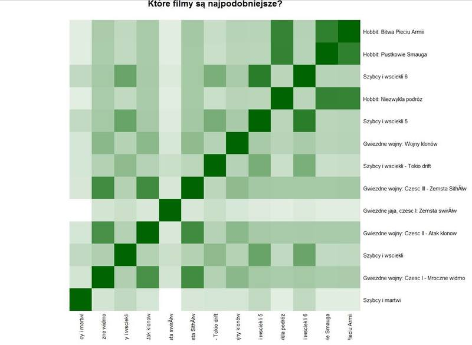

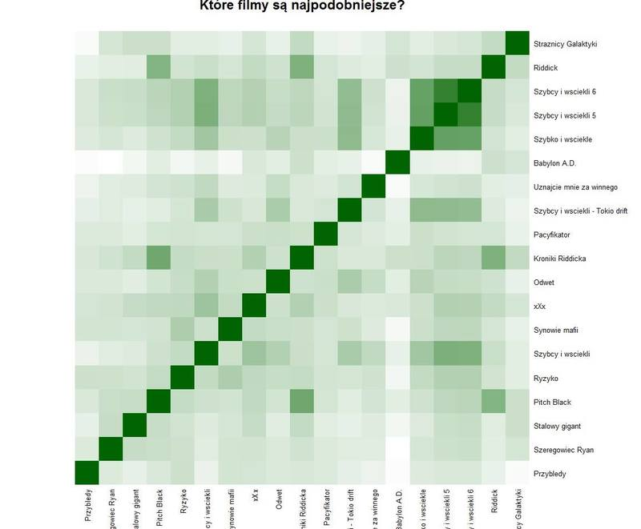